# crasch Tutorial 3 - A Full `crasch` Analysis

Amy E. Arneson

Fall 2016

# Objectives

This tutorial uses sample data files, though you are welcome to use your own files if you have created them. For specific instructions and templates for creating the input files, return to Tutorial 2.

- Import correctly formatted input files.
- Become familiar with the options for the arguments of the `craschR()` function.
- Run post-estimation visualizations and functions.
- Become familiar with the options for the arguments of the post-estimation functions.
- Practice interpreting output.

# `crasch` functions

*Open RStudio, load the `crasch` package, and set your working directory.* If you have not installed the `crasch` package, return to Tutorial 1.

```r
library(crasch)
setwd("C:/Users/Amy/Desktop/SUP") # for Windows
setwd("/Users/Amy/Desktop/SUP")   # for OSX
```

## `craschR()`

### Run Rasch family analysis on response data

```r
?craschR # look at the help file for the function
  # The most relevant arguments to change for our purposes are:
  #    persMethod
  #    writeout
  #    fileSuffix
```

First, we need to load the data. Sample data files are provided in the `Tutorial3-documents` folder on bCourses.

We will use the “Level of Support” construct from the same study described in Tutorial 2.

```r
SUPcons = read.csv("SUPcons.csv", stringsAsFactors = FALSE)
SUPitem = read.csv("SUPitem.csv", stringsAsFactors = FALSE)
SUPscores = read.csv("SUPwide.csv", row.names = 1, stringsAsFactors = FALSE)
SUPvars = read.csv("SUPvars.csv", row.names = 1, stringsAsFactors = FALSE)

# You can view these objects within RStudio to makes sure that they are formatted correctly.
# Always check to make sure the row names aren't imported as a variable column!
```

Let’s run the TAM analysis and play with some of the arguments.

```r
# The default analysis, without writing output to a file
SUPanalysis = craschR(scores = SUPscores, itemInfo = SUPitem,
                      consInfo = SUPcons, varsInfo = SUPvars, writeout = FALSE)

########################### PERSON ESTIMATION METHOD ###########################
# The default person estimation method is EAP
# You can also obtain MLEs or WLEs
SUP_MLE = craschR(scores = SUPscores, itemInfo = SUPitem, consInfo = SUPcons,
                  varsInfo = SUPvars, persMethod = "MLE", writeout = FALSE)
SUP_WLE = craschR(scores = SUPscores, itemInfo = SUPitem, consInfo = SUPcons,
                  varsInfo = SUPvars, persMethod = "WLE", writeout = FALSE)

# View the different estimates in a table
cbind(SUPanalysis$persPars, SUP_MLE$persPars, SUP_WLE$persPars)
```

```
##         SUP_EAP     SUP_MLE     SUP_WLE
## 110  2.18985787  3.29464453  3.17702208
## 111  0.30525507  0.92937160  0.92172272
## 112 -0.10263505  0.37009673  0.36695877
## 113  1.30126651  2.17323354  2.13268443
## 114 -1.21394828 -1.31932617 -1.32477929
## 115 -2.07465423 -2.57471935 -2.54883755
## 116 -0.02256299  0.56037381  0.55411422
## 117  0.20619639  0.93457230  0.91733649
## 118 -0.61528113  0.05977599  0.04076160
## 119 -0.02166735  0.46722820  0.46529561
## 120  1.07679104  1.83778068  1.80419871
## 121  0.25087145  0.89875185  0.90137175
## 122  0.03799394  0.50502402  0.49764947
## 123 -0.47118342 -0.34554854 -0.35664836
```

[output cut: 24 more lines]

```r
############################ FILE WRITEOUT OPTIONS #############################

# Note that writeout=TRUE is the default *only* for craschR
SUPanalysis = craschR(scores = SUPscores, itemInfo = SUPitem,
                      consInfo = SUPcons, varsInfo = SUPvars)
SUP_MLE = craschR(scores = SUPscores, itemInfo = SUPitem, consInfo = SUPcons,
                  varsInfo = SUPvars, persMethod = "MLE", fileSuffix = "MLE")
SUP_WLE = craschR(scores = SUPscores, itemInfo = SUPitem, consInfo = SUPcons,
                  varsInfo = SUPvars, persMethod = "WLE", fileSuffix = "WLE")
# Check your working directory to see the different files

# Note that R will overwrite files with the same name.  Use "fileSuffix" to
#  differentiate between different runs of the same or different data.
```

## `item.scores()`

### Produce tables and graphs for the score distribution by item

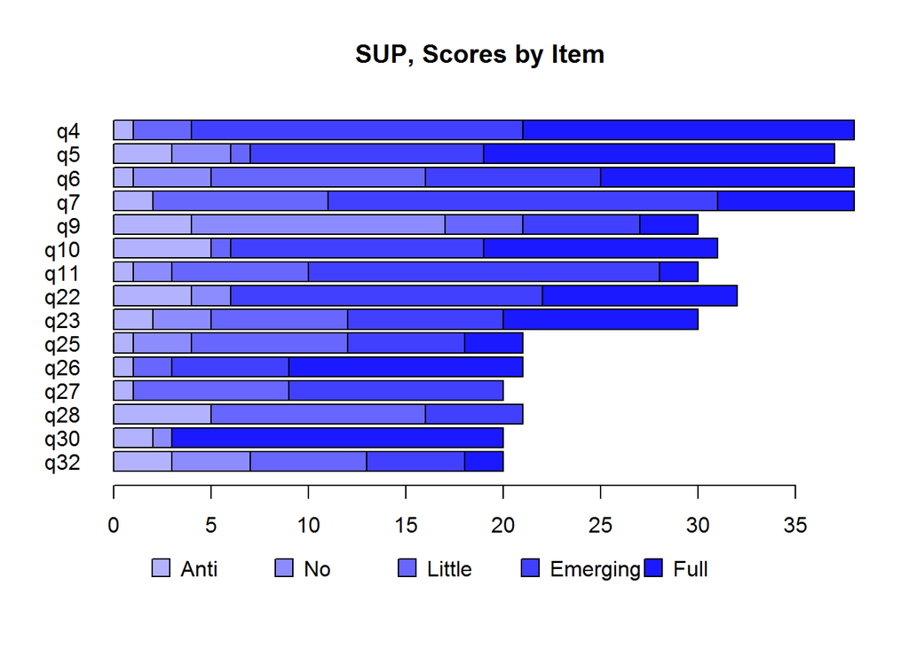

```r
?item.scores
# The most relevant arguments to change for our purposes are:
  #    freqs
  #    palette
  #    imageType

item.scores(SUPanalysis)
```

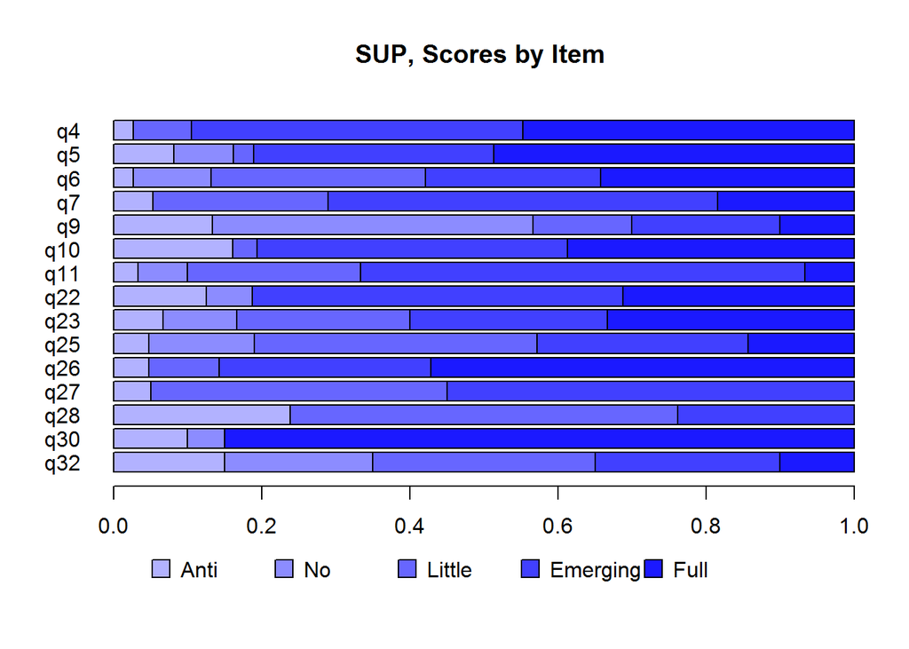

```r
# To graph proportions instead of frequencies, use freqs = FALSE
item.scores(SUPanalysis, freqs = FALSE)
```

Check out the Color Brewer website. It is really helpful in determining color palettes in general for presentations. They even have color-blind-friendly palettes if you want to make a fully-accessible presentation!

colorbrewer2.org